# Copy_of_BANA698_Environmental_Preprocessing

## **Initial Summary Statistics by Region**

```python
import pandas as pd

file_path = "/content/env_stat_summary.csv"
df = pd.read_csv(file_path)
df.head()
```

|  | region | total_records | mean_electricity_access | median_electricity_access | stddev_electricity_access | mean_co2_agriculture | median_co2_agriculture | stddev_co2_agriculture | mean_co2_transport | median_co2_transport | ... | stddev_co2_waste | mean_forest_area | median_forest_area | stddev_forest_area | mean_renewable_energy | median_renewable_energy | stddev_renewable_energy | mean_ghg_emissions | median_ghg_emissions | stddev_ghg_emissions |
| --- | --- | --- | --- | --- | --- | --- | --- | --- | --- | --- | --- | --- | --- | --- | --- | --- | --- | --- | --- | --- | --- |
| 0 | East Asia and Pacific | 111 | 60.251351 | 92.8 | 46.439346 | 0.955335 | 0.0000 | 2.715880 | 48.100141 | 1.7875 | ... | 0.806394 | 30.420019 | 24.226046 | 30.481800 | 9.155856 | 0.4 | 15.781668 | 8.301835 | 3.598783 | 14.196181 |
| 1 | Europe and Central Asia | 174 | 65.508621 | 100.0 | 47.662131 | 0.453471 | 0.0561 | 0.956486 | 23.674526 | 7.5765 | ... | 0.606930 | 18.081419 | 11.029667 | 20.009604 | 7.794253 | 0.0 | 14.852129 | 6.786218 | 6.481516 | 4.463806 |
| 2 | Latin America and the Caribbean | 126 | 65.053175 | 98.6 | 46.664376 | 0.541188 | 0.0000 | 2.034740 | 13.804961 | 1.4529 | ... | 0.087777 | 27.284134 | 24.657473 | 26.519414 | 7.343651 | 0.0 | 14.743712 | 4.300075 | 3.502919 | 4.147293 |
| 3 | Middle East and North Africa | 63 | 63.474603 | 99.9 | 46.073945 | 0.258895 | 0.0148 | 0.668533 | 27.659551 | 14.0773 | ... | 0.000506 | 1.841691 | 0.253378 | 3.516258 | 2.496825 | 0.0 | 5.849978 | 13.353623 | 5.673357 | 15.412068 |
| 4 | North America | 9 | 66.666667 | 100.0 | 50.000000 | 3.357056 | 3.7035 | 2.760139 | 617.959322 | 164.2478 | ... | 0.054469 | 20.411882 | 18.518519 | 17.122551 | 4.055556 | 0.0 | 8.207026 | 14.202102 | 18.062548 | 6.420438 |

5 rows × 23 columns

```python
print(df.dtypes)
df.describe()
```

```
region                        object
total_records                  int64
mean_electricity_access      float64
median_electricity_access    float64
stddev_electricity_access    float64
mean_co2_agriculture         float64
median_co2_agriculture       float64
stddev_co2_agriculture       float64
mean_co2_transport           float64
median_co2_transport         float64
stddev_co2_transport         float64
mean_co2_waste               float64
median_co2_waste             float64
stddev_co2_waste             float64
mean_forest_area             float64
median_forest_area           float64
stddev_forest_area           float64
mean_renewable_energy        float64
median_renewable_energy      float64
stddev_renewable_energy      float64
mean_ghg_emissions           float64
median_ghg_emissions         float64
stddev_ghg_emissions         float64
dtype: object
```

|  | total_records | mean_electricity_access | median_electricity_access | stddev_electricity_access | mean_co2_agriculture | median_co2_agriculture | stddev_co2_agriculture | mean_co2_transport | median_co2_transport | stddev_co2_transport | ... | stddev_co2_waste | mean_forest_area | median_forest_area | stddev_forest_area | mean_renewable_energy | median_renewable_energy | stddev_renewable_energy | mean_ghg_emissions | median_ghg_emissions | stddev_ghg_emissions |
| --- | --- | --- | --- | --- | --- | --- | --- | --- | --- | --- | --- | --- | --- | --- | --- | --- | --- | --- | --- | --- | --- |
| count | 11.000000 | 11.000000 | 11.000000 | 11.000000 | 11.000000 | 11.000000 | 11.000000 | 11.000000 | 11.000000 | 11.000000 | ... | 11.000000 | 11.000000 | 11.000000 | 11.000000 | 11.000000 | 11.000000 | 11.000000 | 11.000000 | 11.000000 | 11.000000 |
| mean | 72.545455 | 54.069737 | 78.349238 | 41.369573 | 18.989543 | 16.710668 | 6.618708 | 989.516938 | 914.784437 | 314.900079 | ... | 0.820917 | 17.800999 | 15.273080 | 18.065251 | 7.177553 | 0.036364 | 11.225868 | 6.330302 | 5.112460 | 5.077793 |
| std | 60.221863 | 19.975532 | 33.136377 | 14.670475 | 43.074597 | 42.963857 | 12.018418 | 2357.049405 | 2374.556666 | 448.471030 | ... | 1.485764 | 9.266937 | 10.974609 | 9.250084 | 9.412986 | 0.120605 | 12.194281 | 4.370993 | 4.776295 | 5.183939 |
| min | 3.000000 | 0.000000 | 0.000000 | 0.000000 | 0.000000 | 0.000000 | 0.000000 | 0.000000 | 0.000000 | 0.000000 | ... | 0.000000 | 0.000000 | 0.000000 | 0.000000 | 0.000000 | 0.000000 | 0.000000 | 0.000000 | 0.000000 | 0.000000 |
| 25% | 16.500000 | 56.372606 | 74.281881 | 43.148112 | 0.356183 | 0.000000 | 0.483669 | 18.739743 | 1.620200 | 38.035241 | ... | 0.001390 | 17.182870 | 6.814998 | 15.714799 | 0.000000 | 0.000000 | 0.000000 | 3.446536 | 2.708384 | 1.877429 |
| 50% | 63.000000 | 60.870948 | 92.800000 | 46.439346 | 0.955335 | 0.056100 | 2.034740 | 48.100141 | 7.576500 | 105.443837 | ... | 0.087777 | 20.127130 | 18.518519 | 20.009604 | 4.055556 | 0.000000 | 8.207026 | 6.312356 | 3.604205 | 3.837602 |
| 75% | 118.500000 | 64.845337 | 99.250000 | 47.246059 | 8.873769 | 4.618100 | 6.315707 | 580.068047 | 286.224850 | 412.782648 | ... | 0.706662 | 21.051773 | 24.441759 | 23.289421 | 8.475054 | 0.000000 | 15.316899 | 7.544026 | 6.020970 | 5.442122 |
| max | 174.000000 | 66.666667 | 100.000000 | 52.715795 | 143.319999 | 143.249643 | 40.605901 | 7939.083771 | 7943.501403 | 1428.492211 | ... | 4.533690 | 30.420019 | 31.143041 | 30.481800 | 30.152778 | 0.400000 | 36.112886 | 14.202102 | 18.062548 | 15.412068 |

8 rows × 22 columns

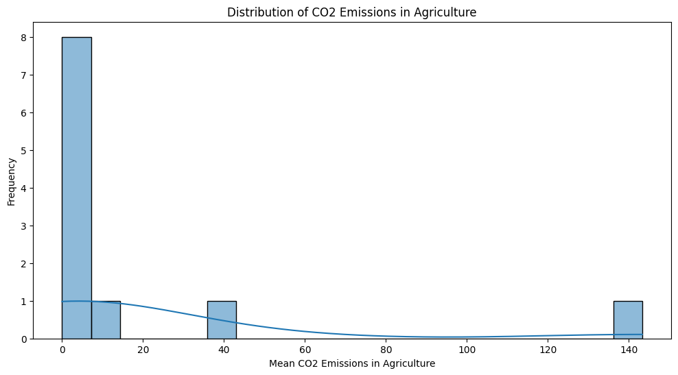

```python
import matplotlib.pyplot as plt
import seaborn as sns

plt.figure(figsize=(12, 6))

sns.histplot(df["mean_co2_agriculture"], bins=20, kde=True)
plt.xlabel("Mean CO2 Emissions in Agriculture")
plt.ylabel("Frequency")
plt.title("Distribution of CO2 Emissions in Agriculture")
plt.show()
```

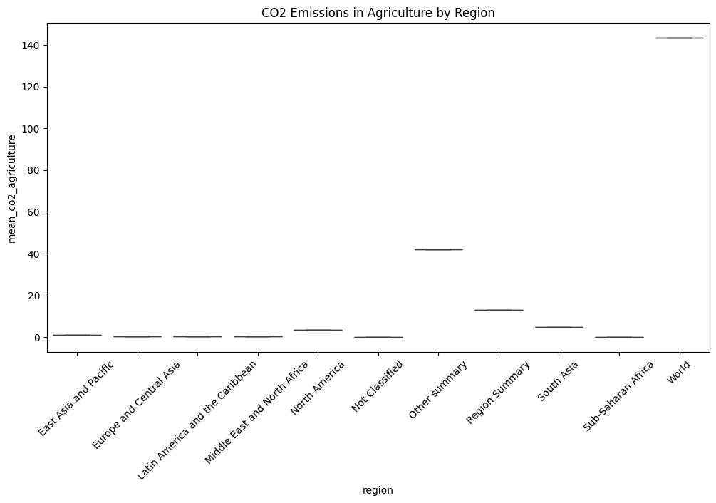

```python
plt.figure(figsize=(12, 6))
sns.boxplot(x="region", y="mean_co2_agriculture", data=df)
plt.xticks(rotation=45)
plt.title("CO2 Emissions in Agriculture by Region")
plt.show()
```

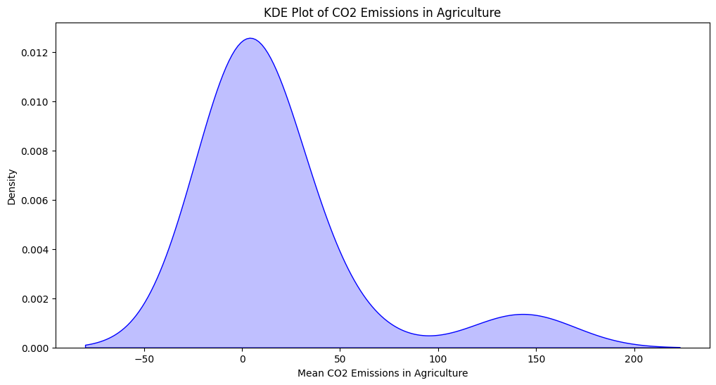

```python
plt.figure(figsize=(12, 6))
sns.kdeplot(df["mean_co2_agriculture"], shade=True, color="blue")
plt.xlabel("Mean CO2 Emissions in Agriculture")
plt.title("KDE Plot of CO2 Emissions in Agriculture")
plt.show()
```

## **Summary Statistics by Country**

```python
import pandas as pd

file_path = "/content/environmental_indicators_join.csv"
df = pd.read_csv(file_path)
df.head()
```

|  | country_code | year | ElectricityAccess_PercentofPopulation | CO2Emissions_Agriculture | CO2Emissions_TransportEnergy | CO2Emissions_Waste | ForestArea_PercentofLand | RenewableEnergy_Consumption_Percent | GreenhouseGasEmissions_TotalperCapita | country_name | Region |
| --- | --- | --- | --- | --- | --- | --- | --- | --- | --- | --- | --- |
| 0 | ABW | 2019 | 100.0 | .. | 0.2064 | .. | 2.333333333 | 8.3 | 5.393624717 | Aruba | Latin America and the Caribbean |
| 1 | ABW | 2020 | 100.0 | .. | 0.1537 | .. | 2.333333333 | 9.1 | 4.440678903 | Aruba | Latin America and the Caribbean |
| 2 | ABW | 2021 | 100.0 | .. | 0.1706 | .. | 2.333333333 | 8.8 | 4.932219127 | Aruba | Latin America and the Caribbean |
| 3 | ABW | 2022 | 99.9 | .. | 0.1749 | .. | 2.333333333 | 8.8 | 4.972509552 | Aruba | Latin America and the Caribbean |
| 4 | ABW | 2023 | .. | .. | 0.1864 | .. | .. | .. | 5.23011578 | Aruba | Latin America and the Caribbean |

```python
# Check the data types and missing values
df.info()
df.describe()
```

```
<class 'pandas.core.frame.DataFrame'>
RangeIndex: 1330 entries, 0 to 1329
Data columns (total 11 columns):
 #   Column                                 Non-Null Count  Dtype
---  ------                                 --------------  -----
 0   country_code                           1330 non-null   object
 1   year                                   1330 non-null   int64
 2   ElectricityAccess_PercentofPopulation  1330 non-null   object
 3   CO2Emissions_Agriculture               1330 non-null   object
 4   CO2Emissions_TransportEnergy           1330 non-null   object
 5   CO2Emissions_Waste                     1330 non-null   object
 6   ForestArea_PercentofLand               1330 non-null   object
 7   RenewableEnergy_Consumption_Percent    1330 non-null   object
 8   GreenhouseGasEmissions_TotalperCapita  1330 non-null   object
 9   country_name                           1330 non-null   object
 10  Region                                 1330 non-null   object
dtypes: int64(1), object(10)
memory usage: 114.4+ KB
```

|  | year |
| --- | --- |
| count | 1330.000000 |
| mean | 2021.000000 |
| std | 1.414746 |
| min | 2019.000000 |
| 25% | 2020.000000 |
| 50% | 2021.000000 |
| 75% | 2022.000000 |
| max | 2023.000000 |

### **Preprocessing for Indicator: Electricity Access %**

```python
# Convert the column to numeric values
df["ElectricityAccess_PercentofPopulation"] = pd.to_numeric(df["ElectricityAccess_PercentofPopulation"], errors='coerce')

# Now you can check for invalid values
invalid_values = df[(df["ElectricityAccess_PercentofPopulation"] < 0) | (df["ElectricityAccess_PercentofPopulation"] > 100)]
```

**Check for outliers based on IQR:**

```python
import numpy as np

col = "ElectricityAccess_PercentofPopulation"

Q1 = df[col].quantile(0.25)
Q3 = df[col].quantile(0.75)
IQR = Q3 - Q1

lower_bound = Q1 - 1.5 * IQR
upper_bound = Q3 + 1.5 * IQR

outliers = df[(df[col] < lower_bound) | (df[col] > upper_bound)]
outliers
```

|  | country_code | year | ElectricityAccess_PercentofPopulation | CO2Emissions_Agriculture | CO2Emissions_TransportEnergy | CO2Emissions_Waste | ForestArea_PercentofLand | RenewableEnergy_Consumption_Percent | GreenhouseGasEmissions_TotalperCapita | country_name | Region |
| --- | --- | --- | --- | --- | --- | --- | --- | --- | --- | --- | --- |
| 5 | AFE | 2019 | 44.390861 | 1.8687 | 123.1346 | 0.0028 | 30.39162586 | 63.3870897 | 2.217915024 | Africa Eastern and Southern | Region Summary |
| 6 | AFE | 2020 | 46.282371 | 2.1285 | 108.1085 | 0.0029 | 30.17425244 | 66.1234487 | 2.079385919 | Africa Eastern and Southern | Region Summary |
| 7 | AFE | 2021 | 48.127211 | 2.5883 | 121.368 | 0.003 | 29.95519379 | .. | 2.056051687 | Africa Eastern and Southern | Region Summary |
| 8 | AFE | 2022 | 48.742043 | 2.6171 | 120.0506 | 0.0031 | 29.7372051 | .. | 2.003239827 | Africa Eastern and Southern | Region Summary |
| 15 | AFW | 2019 | 51.291577 | 1.1848 | 100.7277 | 0.0101 | 19.90123011 | 75.32892838 | 1.908940643 | Africa Western and Central | Region Summary |
| ... | ... | ... | ... | ... | ... | ... | ... | ... | ... | ... | ... |
| 1323 | ZMB | 2022 | 47.800000 | 0.2146 | 2.3576 | .. | 59.77696915 | .. | 1.480965207 | Zambia | Sub-Saharan Africa |
| 1325 | ZWE | 2019 | 46.700000 | 0.0623 | 2.2368 | .. | 45.21300246 | 81.0 | 1.857685572 | Zimbabwe | Sub-Saharan Africa |
| 1326 | ZWE | 2020 | 52.700000 | 0.0748 | 1.5124 | .. | 45.09391237 | 84.1 | 1.724144594 | Zimbabwe | Sub-Saharan Africa |
| 1327 | ZWE | 2021 | 49.000000 | 0.1004 | 1.5847 | .. | 44.97482228 | 82.4 | 1.82806964 | Zimbabwe | Sub-Saharan Africa |
| 1328 | ZWE | 2022 | 50.100000 | 0.097 | 1.4742 | .. | 44.8557322 | .. | 1.856076673 | Zimbabwe | Sub-Saharan Africa |

188 rows × 11 columns

**Keep indicator data as is - all values are withing expected ranges, as the indicator should be a percentage between 0-100**

```python
# Count zero values in each CO₂ emissions column
co2_columns = ["CO2Emissions_Agriculture", "CO2Emissions_TransportEnergy", "CO2Emissions_Waste"]
zero_counts = (df[co2_columns] == 0).sum()
print("Zero values in CO₂ emissions columns:\n", zero_counts)
```

```
Zero values in CO₂ emissions columns:
 CO2Emissions_Agriculture        0
CO2Emissions_TransportEnergy    0
CO2Emissions_Waste              0
dtype: int64
```

```python
# Convert columns to numeric values first
df["CO2Emissions_Agriculture"] = pd.to_numeric(df["CO2Emissions_Agriculture"], errors='coerce')
df["CO2Emissions_TransportEnergy"] = pd.to_numeric(df["CO2Emissions_TransportEnergy"], errors='coerce')
df["CO2Emissions_Waste"] = pd.to_numeric(df["CO2Emissions_Waste"], errors='coerce')

# Now run your outlier detection
outliers_agriculture = detect_outliers_iqr(df, "CO2Emissions_Agriculture")
outliers_transport = detect_outliers_iqr(df, "CO2Emissions_TransportEnergy")
outliers_waste = detect_outliers_iqr(df, "CO2Emissions_Waste")

print("Outliers detected:")
print(f"Agriculture: {len(outliers_agriculture)}")
print(f"Transport: {len(outliers_transport)}")
print(f"Waste: {len(outliers_waste)}")
```

```
Outliers detected:
Agriculture: 127
Transport: 184
Waste: 137
```

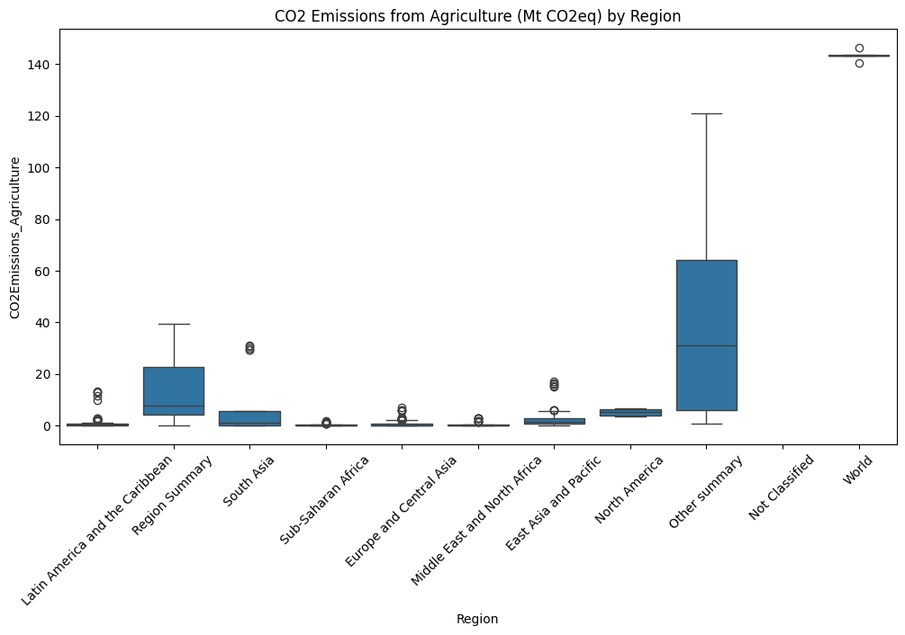

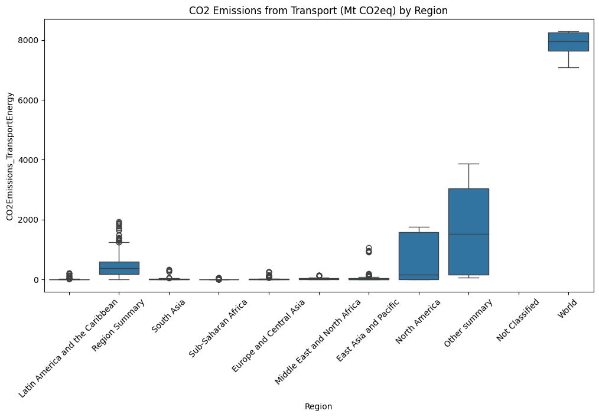

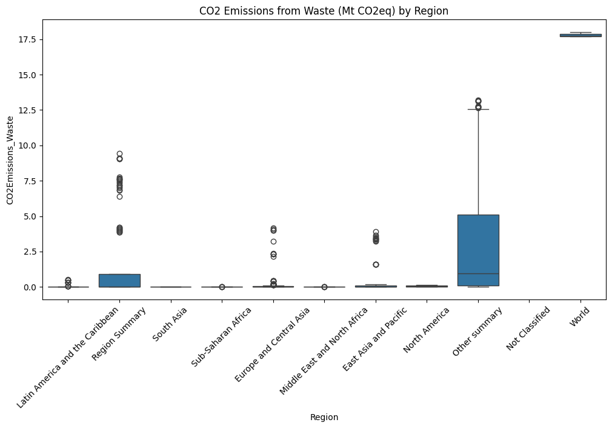

```python
import seaborn as sns
import matplotlib.pyplot as plt

def plot_boxplot(column, title):
    plt.figure(figsize=(12, 6))
    sns.boxplot(x="Region", y=column, data=df)
    plt.xticks(rotation=45)
    plt.title(title)
    plt.show()

plot_boxplot("CO2Emissions_Agriculture", "CO2 Emissions from Agriculture (Mt CO2eq) by Region")
plot_boxplot("CO2Emissions_TransportEnergy", "CO2 Emissions from Transport (Mt CO2eq) by Region")
plot_boxplot("CO2Emissions_Waste", "CO2 Emissions from Waste (Mt CO2eq) by Region")
```

**Remove certain region labels, given they are not actual regions and are instead categories summarized at a different level**

```python
excluded_regions = ["Region Summary", "World", "Other summary", "Not Classified"]

df_filtered = df[~df["Region"].isin(excluded_regions)].copy()

print("Remaining Regions in Dataset:", df_filtered["Region"].unique())
```

```
Remaining Regions in Dataset: ['Latin America and the Caribbean' 'South Asia' 'Sub-Saharan Africa'
 'Europe and Central Asia' 'Middle East and North Africa'
 'East Asia and Pacific' 'North America']
```

**Check for outliers again with filtered regions. Result is less outliers based on IQR**

```python
def detect_outliers_iqr(data, column):
    Q1 = data[column].quantile(0.25)
    Q3 = data[column].quantile(0.75)
    IQR = Q3 - Q1
    lower_bound = Q1 - 1.5 * IQR
    upper_bound = Q3 + 1.5 * IQR

    outliers = data[(data[column] < lower_bound) | (data[column] > upper_bound)]

    return outliers

outliers_agriculture = detect_outliers_iqr(df_filtered, "CO2Emissions_Agriculture")
outliers_transport = detect_outliers_iqr(df_filtered, "CO2Emissions_TransportEnergy")
outliers_waste = detect_outliers_iqr(df_filtered, "CO2Emissions_Waste")

print("Outliers detected (after filtering regions):")
print(f"Agriculture: {len(outliers_agriculture)}")
print(f"Transport: {len(outliers_transport)}")
print(f"Waste: {len(outliers_waste)}")
```

```
Outliers detected (after filtering regions):
Agriculture: 66
Transport: 144
Waste: 98
```

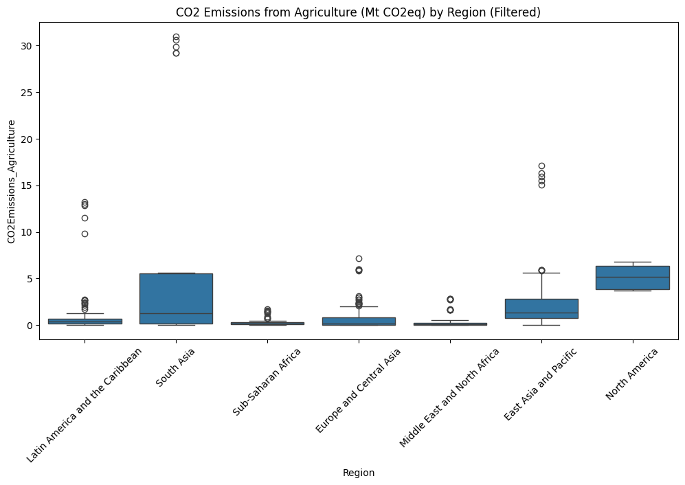

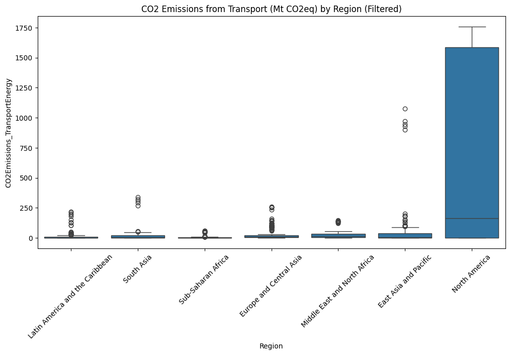

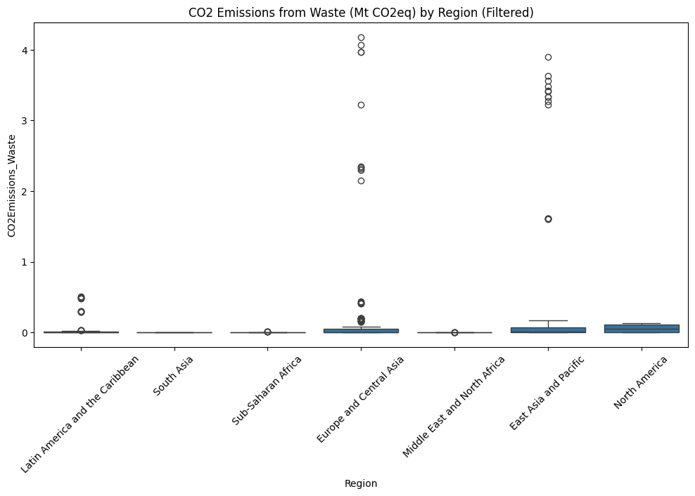

```python
def plot_boxplot(data, column, title):
    plt.figure(figsize=(12, 6))
    sns.boxplot(x="Region", y=column, data=data)
    plt.xticks(rotation=45)
    plt.title(title)
    plt.show()

plot_boxplot(df_filtered, "CO2Emissions_Agriculture", "CO2 Emissions from Agriculture (Mt CO2eq) by Region (Filtered)")
plot_boxplot(df_filtered, "CO2Emissions_TransportEnergy", "CO2 Emissions from Transport (Mt CO2eq) by Region (Filtered)")
plot_boxplot(df_filtered, "CO2Emissions_Waste", "CO2 Emissions from Waste (Mt CO2eq) by Region (Filtered)")
```

**There are still regions with outliers (as shown by the boxplots), however these outliers may be acceptable (i.e., there may be some countries that are expected to have significantly higher CO2 Emissions than others)**

```python
def get_top_10_emitters(data, column):
    return data[["country_name", "Region", column]].sort_values(by=column, ascending=False).head(10)

top_10_agriculture = get_top_10_emitters(df_filtered, "CO2Emissions_Agriculture")
top_10_transport = get_top_10_emitters(df_filtered, "CO2Emissions_TransportEnergy")
top_10_waste = get_top_10_emitters(df_filtered, "CO2Emissions_Waste")

print("Top 10 Countries for CO2 Emissions from Agriculture:\n")
display(top_10_agriculture)

print("Top 10 Countries for CO2 Emissions from Transport:\n")
display(top_10_transport)

print("Top 10 Countries for CO2 Emissions from Waste:\n")
display(top_10_waste)
```

```
Top 10 Countries for CO2 Emissions from Agriculture:
```

|  | country_name | Region | CO2Emissions_Agriculture |
| --- | --- | --- | --- |
| 546 | India | South Asia | 30.9691 |
| 549 | India | South Asia | 30.5827 |
| 548 | India | South Asia | 29.9048 |
| 547 | India | South Asia | 29.2446 |
| 545 | India | South Asia | 29.1932 |
| 200 | China | East Asia and Pacific | 17.1319 |
| 201 | China | East Asia and Pacific | 16.2812 |
| 202 | China | East Asia and Pacific | 15.9153 |
| 203 | China | East Asia and Pacific | 15.4808 |
| 204 | China | East Asia and Pacific | 15.0616 |

```
Top 10 Countries for CO2 Emissions from Transport:
```

|  | country_name | Region | CO2Emissions_TransportEnergy |
| --- | --- | --- | --- |
| 1255 | United States | North America | 1757.3448 |
| 1259 | United States | North America | 1710.6454 |
| 1258 | United States | North America | 1699.4280 |
| 1257 | United States | North America | 1663.6783 |
| 1256 | United States | North America | 1507.9152 |
| 204 | China | East Asia and Pacific | 1077.7615 |
| 202 | China | East Asia and Pacific | 969.4479 |
| 200 | China | East Asia and Pacific | 944.3723 |
| 203 | China | East Asia and Pacific | 929.0863 |
| 201 | China | East Asia and Pacific | 901.9615 |

```
Top 10 Countries for CO2 Emissions from Waste:
```

|  | country_name | Region | CO2Emissions_Waste |
| --- | --- | --- | --- |
| 354 | Spain | Europe and Central Asia | 4.1758 |
| 353 | Spain | Europe and Central Asia | 4.0727 |
| 352 | Spain | Europe and Central Asia | 3.9722 |
| 351 | Spain | Europe and Central Asia | 3.9722 |
| 595 | Japan | East Asia and Pacific | 3.8988 |
| 204 | China | East Asia and Pacific | 3.6358 |
| 203 | China | East Asia and Pacific | 3.5582 |
| 202 | China | East Asia and Pacific | 3.4822 |
| 596 | Japan | East Asia and Pacific | 3.4216 |
| 201 | China | East Asia and Pacific | 3.4124 |

**The countries in the lists above are highly populated and can be expected to have higher than average C02 Emissions**

### **Preprocessing for Indicators: Forest Area % AND Renewable Energy Consumption %**

```python
# Convert columns to numeric values first
df_filtered["ForestArea_PercentofLand"] = pd.to_numeric(df_filtered["ForestArea_PercentofLand"], errors='coerce')
df_filtered["RenewableEnergy_Consumption_Percent"] = pd.to_numeric(df_filtered["RenewableEnergy_Consumption_Percent"], errors='coerce')

# Now check for invalid values
invalid_forest = df_filtered[(df_filtered["ForestArea_PercentofLand"] < 0) | (df_filtered["ForestArea_PercentofLand"] > 100)]
invalid_renewable = df_filtered[(df_filtered["RenewableEnergy_Consumption_Percent"] < 0) | (df_filtered["RenewableEnergy_Consumption_Percent"] > 100)]

print("Invalid Values in Forest Area (% of land):")
display(invalid_forest)

print("Invalid Values in Renewable Energy Consumption (% of total energy use):")
display(invalid_renewable)
```

```
Invalid Values in Forest Area (% of land):
```

|  | country_code | year | ElectricityAccess_PercentofPopulation | CO2Emissions_Agriculture | CO2Emissions_TransportEnergy | CO2Emissions_Waste | ForestArea_PercentofLand | RenewableEnergy_Consumption_Percent | GreenhouseGasEmissions_TotalperCapita | country_name | Region |
| --- | --- | --- | --- | --- | --- | --- | --- | --- | --- | --- | --- |

```
Invalid Values in Renewable Energy Consumption (% of total energy use):
```

|  | country_code | year | ElectricityAccess_PercentofPopulation | CO2Emissions_Agriculture | CO2Emissions_TransportEnergy | CO2Emissions_Waste | ForestArea_PercentofLand | RenewableEnergy_Consumption_Percent | GreenhouseGasEmissions_TotalperCapita | country_name | Region |
| --- | --- | --- | --- | --- | --- | --- | --- | --- | --- | --- | --- |

```python
def detect_outliers_iqr(data, column):
    Q1 = data[column].quantile(0.25)
    Q3 = data[column].quantile(0.75)
    IQR = Q3 - Q1
    lower_bound = Q1 - 1.5 * IQR
    upper_bound = Q3 + 1.5 * IQR

    outliers = data[(data[column] < lower_bound) | (data[column] > upper_bound)]

    return outliers[["country_name", "Region", column]]

outliers_forest = detect_outliers_iqr(df_filtered, "ForestArea_PercentofLand")
outliers_renewable = detect_outliers_iqr(df_filtered, "RenewableEnergy_Consumption_Percent")

print("Outliers in Forest Area (% of land):")
display(outliers_forest)

print("Outliers in Renewable Energy Consumption (% of total energy use):")
display(outliers_renewable)
```

```
Outliers in Forest Area (% of land):
```

|  | country_name | Region | ForestArea_PercentofLand |
| --- | --- | --- | --- |

```
Outliers in Renewable Energy Consumption (% of total energy use):
```

|  | country_name | Region | RenewableEnergy_Consumption_Percent |
| --- | --- | --- | --- |

**All values for both indicators are within the expected range for percentages (0-100)**

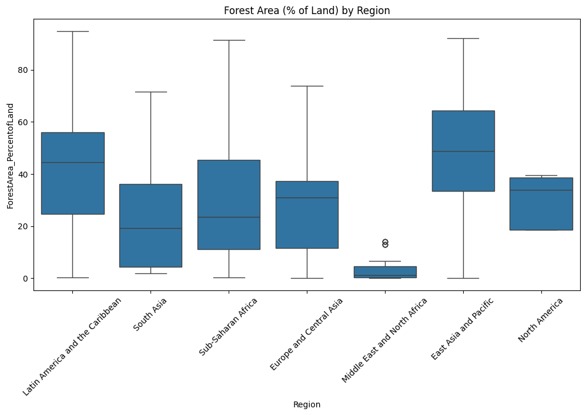

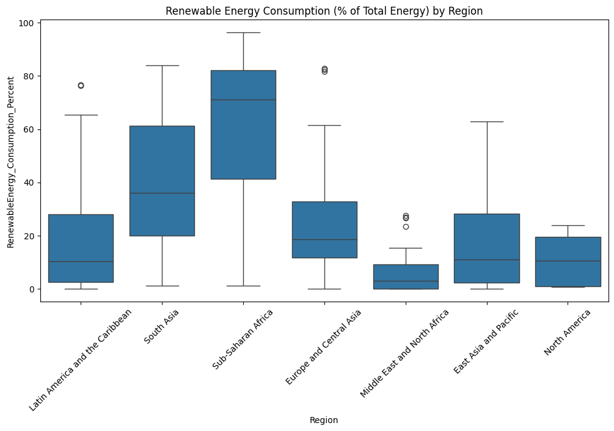

```python
def plot_boxplot(data, column, title):
    plt.figure(figsize=(12, 6))
    sns.boxplot(x="Region", y=column, data=data)
    plt.xticks(rotation=45)
    plt.title(title)
    plt.show()

plot_boxplot(df_filtered, "ForestArea_PercentofLand", "Forest Area (% of Land) by Region")
plot_boxplot(df_filtered, "RenewableEnergy_Consumption_Percent", "Renewable Energy Consumption (% of Total Energy) by Region")
```

```python
zero_ghg = df_filtered[df_filtered["GreenhouseGasEmissions_TotalperCapita"] == 0]

print("Countries with Zero GHG Emissions per Capita:")
display(zero_ghg)
```

```
Countries with Zero GHG Emissions per Capita:
```

|  | country_code | year | ElectricityAccess_PercentofPopulation | CO2Emissions_Agriculture | CO2Emissions_TransportEnergy | CO2Emissions_Waste | ForestArea_PercentofLand | RenewableEnergy_Consumption_Percent | GreenhouseGasEmissions_TotalperCapita | country_name | Region |
| --- | --- | --- | --- | --- | --- | --- | --- | --- | --- | --- | --- |

### **Preprocessing for Indicators: Greenhouse Gas Emissions per Capita**

```python
# Convert the GHG emissions column to numeric
df_filtered["GreenhouseGasEmissions_TotalperCapita"] = pd.to_numeric(df_filtered["GreenhouseGasEmissions_TotalperCapita"], errors='coerce')

# Now detect outliers
outliers_ghg = detect_outliers_iqr(df_filtered, "GreenhouseGasEmissions_TotalperCapita")

print("Outliers in Total GHG Emissions per Capita (t CO₂e/capita):")
display(outliers_ghg)
```

```
Outliers in Total GHG Emissions per Capita (t CO₂e/capita):
```

|  | country_name | Region | GreenhouseGasEmissions_TotalperCapita |
| --- | --- | --- | --- |
| 40 | United Arab Emirates | Middle East and North Africa | 26.635224 |
| 41 | United Arab Emirates | Middle East and North Africa | 26.520869 |
| 42 | United Arab Emirates | Middle East and North Africa | 26.836639 |
| 43 | United Arab Emirates | Middle East and North Africa | 26.564120 |
| 44 | United Arab Emirates | Middle East and North Africa | 25.546505 |
| ... | ... | ... | ... |
| 1255 | United States | North America | 18.921383 |
| 1256 | United States | North America | 17.107522 |
| 1257 | United States | North America | 18.062548 |
| 1258 | United States | North America | 18.142017 |
| 1259 | United States | North America | 17.797967 |

80 rows × 3 columns

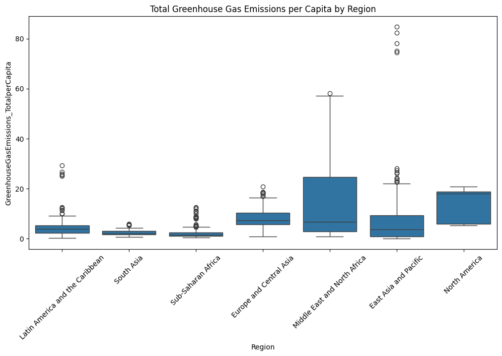

```python
plot_boxplot(df_filtered, "GreenhouseGasEmissions_TotalperCapita", "Total Greenhouse Gas Emissions per Capita by Region")
```

**Expected range for tCO2 e/capita is 2-20, review values outside of that range**

```python
invalid_ghg = df_filtered[(df_filtered["GreenhouseGasEmissions_TotalperCapita"] < 2) |
                          (df_filtered["GreenhouseGasEmissions_TotalperCapita"] > 20)]
print("Countries with GHG Emissions Outside Expected Range (2-20 t CO₂e/capita):")
display(invalid_ghg)
```

```
Countries with GHG Emissions Outside Expected Range (2-20 t CO₂e/capita):
```

|  | country_code | year | ElectricityAccess_PercentofPopulation | CO2Emissions_Agriculture | CO2Emissions_TransportEnergy | CO2Emissions_Waste | ForestArea_PercentofLand | RenewableEnergy_Consumption_Percent | GreenhouseGasEmissions_TotalperCapita | country_name | Region |
| --- | --- | --- | --- | --- | --- | --- | --- | --- | --- | --- | --- |
| 10 | AFG | 2019 | 97.7 | 0.1513 | 1.8897 | NaN | 1.852782 | 18.9 | 0.712772 | Afghanistan | South Asia |
| 11 | AFG | 2020 | 97.7 | 0.0648 | 1.9661 | NaN | 1.852782 | 18.2 | 0.682032 | Afghanistan | South Asia |
| 12 | AFG | 2021 | 97.7 | 0.0467 | 2.1142 | NaN | 1.852782 | 20.0 | 0.691070 | Afghanistan | South Asia |
| 13 | AFG | 2022 | 85.3 | 0.0236 | 2.2472 | NaN | 1.852782 | 20.0 | 0.705148 | Afghanistan | South Asia |
| 14 | AFG | 2023 | NaN | 0.0151 | 2.3412 | NaN | NaN | NaN | 0.710657 | Afghanistan | South Asia |
| ... | ... | ... | ... | ... | ... | ... | ... | ... | ... | ... | ... |
| 1325 | ZWE | 2019 | 46.7 | 0.0623 | 2.2368 | NaN | 45.213002 | 81.0 | 1.857686 | Zimbabwe | Sub-Saharan Africa |
| 1326 | ZWE | 2020 | 52.7 | 0.0748 | 1.5124 | NaN | 45.093912 | 84.1 | 1.724145 | Zimbabwe | Sub-Saharan Africa |
| 1327 | ZWE | 2021 | 49.0 | 0.1004 | 1.5847 | NaN | 44.974822 | 82.4 | 1.828070 | Zimbabwe | Sub-Saharan Africa |
| 1328 | ZWE | 2022 | 50.1 | 0.0970 | 1.4742 | NaN | 44.855732 | NaN | 1.856077 | Zimbabwe | Sub-Saharan Africa |
| 1329 | ZWE | 2023 | NaN | 0.0963 | 1.4784 | NaN | NaN | NaN | 1.898270 | Zimbabwe | Sub-Saharan Africa |

338 rows × 11 columns

**Calculate median for GHG emissions per capita by REGION**

**Apply median imputation to replace GHG values outside of the expected range with the median**

```python
regional_medians = df_filtered.groupby("Region")["GreenhouseGasEmissions_TotalperCapita"].transform("median")

df_filtered["GreenhouseGasEmissions_TotalperCapita"] = df_filtered["GreenhouseGasEmissions_TotalperCapita"].mask(
    (df_filtered["GreenhouseGasEmissions_TotalperCapita"] < 2) |
    (df_filtered["GreenhouseGasEmissions_TotalperCapita"] > 20),
    regional_medians
)
```

## **Final Summary Statistics Post-Cleaning: Environmental_Indicators table**

```python
summary_stats = df_filtered.describe()

print("Summary Statistics for Cleaned Environmental Data:")
display(summary_stats)
```

```
Summary Statistics for Cleaned Environmental Data:
```

|  | year | ElectricityAccess_PercentofPopulation | CO2Emissions_Agriculture | CO2Emissions_TransportEnergy | CO2Emissions_Waste | ForestArea_PercentofLand | RenewableEnergy_Consumption_Percent | GreenhouseGasEmissions_TotalperCapita |
| --- | --- | --- | --- | --- | --- | --- | --- | --- |
| count | 1085.000000 | 860.000000 | 545.000000 | 970.000000 | 490.000000 | 852.000000 | 707.000000 | 1015.000000 |
| mean | 2021.000000 | 86.879651 | 1.311539 | 34.430893 | 0.181169 | 31.870045 | 29.120368 | 5.339303 |
| std | 1.414866 | 23.804070 | 3.549427 | 143.028038 | 0.674640 | 24.171820 | 27.850897 | 3.730097 |
| min | 2019.000000 | 6.800000 | 0.000000 | 0.021800 | 0.000000 | 0.000000 | 0.000000 | 1.595552 |
| 25% | 2020.000000 | 86.225000 | 0.064300 | 1.009175 | 0.000500 | 11.073684 | 6.200000 | 2.524093 |
| 50% | 2021.000000 | 100.000000 | 0.186900 | 4.189250 | 0.002600 | 30.998155 | 19.500000 | 4.109914 |
| 75% | 2022.000000 | 100.000000 | 1.056000 | 16.028625 | 0.019675 | 49.943160 | 47.350000 | 6.836154 |
| max | 2023.000000 | 100.000000 | 30.969100 | 1757.344800 | 4.175800 | 94.752704 | 96.300000 | 19.887338 |

## **Export cleaned table to .csv**

```python
export_path = "/content/cleaned_environmental_indicators.csv"

df_filtered.to_csv(export_path, index=False)

print("Cleaned dataset saved as: {export_path}")
```

[output not shown]

```python
!jupyter nbconvert --to html "/content/BANA698_Environmental_Preprocessing.ipynb"
```

[output not shown]

[output cut: 136 more lines]

[output not shown]